# Greg Morton Reporting Memo

## Angle 1: Has government distrust and ineffectiveness made people more open to dictatorship?

The slight majority of incarcerated people (50.6%) in our survey were open to Trump’s promise to be a “dictator only on the first day of his second term.” Nearly 20% said that it would “definitely be a good idea” for the country.

```r
trump_dictator_first_day %>%
  summarise(
    count_good = sum(count_definitely_good, count_probably_good, na.rm = T),
    count_bad = sum(count_definitely_bad, count_probably_bad, na.rm = T),
    pct_good = count_good / sum(respondents, na.rm = T),
    pct_bad = count_bad / sum(respondents, na.rm = T)
  ) %>%
  kbl() %>%
  kable_material()
```

| count_good | count_bad | pct_good | pct_bad |
| --- | --- | --- | --- |
| 3694 | 2837 | 0.5058888 | 0.3885237 |

Considering the population being surveyed, this surprising result would be an interesting lens through which to explore both the broader dissatisfaction with the federal government, and how incarcerated people view their own highly regimented, authoritarian environments.

The former is evident in other results from the same survey data. Independents nearly outnumbered Democrats and Republicans combined. Pressed on party allegiance, the majority of incarcerated independent voters answered “Neither.” Fewer than one in four of all surveyed saw their vote in federal elections as their most important. This section would expand on [scholarly work](https://academic.oup.com/ia/article/94/3/515/4992409?utm_source=chatgpt.com&login=false) on how negative perceptions of government and democratic institutions can lay the groundwork for authoritarianism.

To further examine the latter point, I’d like to obtain additional survey data that asks about perceptions of authoritarianism and how incarcerated people define terms like “dictatorship.” Secondly, I’d like to do a more robust analysis on the relationship between time served, experience while incarcerated, and political beliefs. Here, I’d like to ask questions about how incarcerated people think about whether living in such a restrictive environment has made a positive or negative impact on their lives personally. While analysis of the relationship between time served and political beliefs is technically possible with the data I have, as I illustrate below, the number of facilities sampled is too small to draw any meaningful conclusions.

```r
# We only have 'sentence served so far' data for a few facilities
sentence_so_far_served %>%
  left_join(trump_dictator_first_day,
            by = c("facility_name" = "facility_name",
                   "state" = "state")) %>%
  ungroup() %>%
  group_by(facility_name) %>%
  summarise(
    respondents_served_so_far = sum(respondents.x, na.rm = T),
    respondents_dictator = sum(respondents.y, na.rm = T),
  ) %>%
  kbl() %>%
  # make this guy a little wider with scrolling
  kable_material("hover") %>%
  kable_styling(bootstrap_options = c("striped", "hover", "condensed")) %>%
  scroll_box(width = "100%", height = "400px")
```

| facility_name | respondents_served_so_far | respondents_dictator |
| --- | --- | --- |
| GEO Group-Kinney County, TX | 16 | 15 |
| MTC: Giles Dalby, TX | 86 | 87 |
| WV DCR Central Regional Jail | 23 | 23 |
| WV DCR North Central Regional Jail | 72 | 69 |
| WV DCR Potomac Highlands Regional Jail | 15 | 0 |
| WV DCR South Central Regional Jail | 23 | 24 |
| WV DCR Southern Regional Jail | 18 | 16 |
| WV DCR Southwestern Regional Jail | 36 | 31 |
| WV DCR Tygart Valley Regional Jail | 38 | 36 |
| WV DCR Western Regional Jail | 27 | 28 |

## Angle 2: Civic engagement culture in jails and prisons

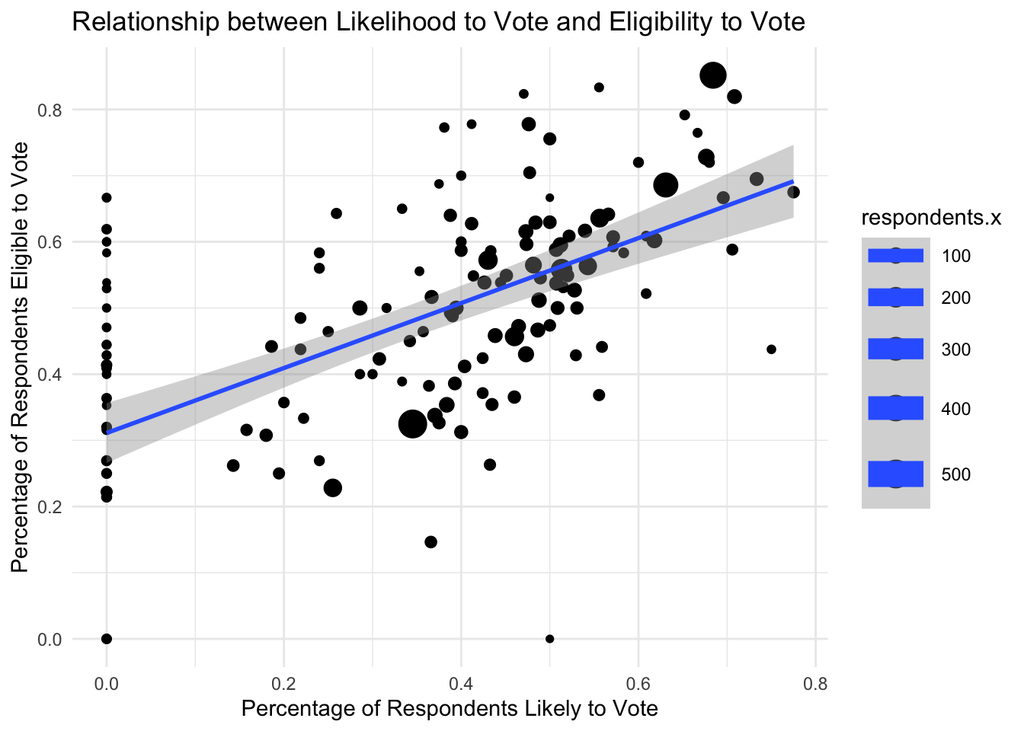

```r
# What's the relationship between likelihood to vote and eligibility to vote?
likely_to_vote %>%
  left_join(eligible_to_vote,
            by = c("facility_name" = "facility_name",
                                     "state" = "state")) %>%
  group_by(facility_name, state) %>%
  mutate(voter_pct = sum(pct_of_respondents_probably_will_vote, pct_of_respondents_definitely_will_vote, na.rm = T)) %>%
  ungroup() %>%
  # filter(voter_pct > 0)
  ggplot(aes(x = voter_pct, y = pct_of_respondents_yes, size = respondents.x)) +
  geom_point() +
  geom_smooth(method = "lm") +
  labs(
    x = "Percentage of Respondents Likely to Vote",
    y = "Percentage of Respondents Eligible to Vote",
    title = "Relationship between Likelihood to Vote and Eligibility to Vote"
  ) +
  theme_minimal()
```

```r
# sanity check with a linear model
eligible_vs_likely_model <-
  likely_to_vote %>%
  left_join(eligible_to_vote,
            by = c("facility_name" = "facility_name",
                                     "state" = "state")) %>%
  group_by(facility_name, state) %>%
  mutate(voter_pct = sum(pct_of_respondents_probably_will_vote, pct_of_respondents_definitely_will_vote, na.rm = T)) %>%
  ungroup() %>%
  lm(pct_of_respondents_yes ~ voter_pct, data = .)

summary(eligible_vs_likely_model)
```

```
Call:
lm(formula = pct_of_respondents_yes ~ voter_pct, data = .)

Residuals:
     Min       1Q   Median       3Q      Max
-0.55652 -0.08748  0.00921  0.09529  0.35559

Coefficients:
            Estimate Std. Error t value Pr(>|t|)
(Intercept)  0.31108    0.02292  13.573  < 2e-16 ***
voter_pct    0.49088    0.05651   8.687 6.13e-15 ***
---
Signif. codes:  0 '***' 0.001 '**' 0.01 '*' 0.05 '.' 0.1 ' ' 1

Residual standard error: 0.1572 on 149 degrees of freedom
  (1 observation deleted due to missingness)
Multiple R-squared:  0.3362,    Adjusted R-squared:  0.3317
F-statistic: 75.46 on 1 and 149 DF,  p-value: 6.133e-15
```

I’d like to use this relationship as a jumping off point to explore the culture of civic engagement in jails and prisons. I’d like to interview incarcerated people about their experiences voting, and how they view the process. I’d also like to interview prison officials and state lawmakers about how they view their role in facilitating voting.

I also like the idea of diving into outliers. Specifically, facilities where the majority of people are eligible to vote, but few are likely to vote. This could be a sign of a lack of access to the ballot, or a lack of interest in voting. Conversely I think it’s also important to look at where civic participation is highest.

```r
# i hate voting
likely_to_vote %>%
  left_join(eligible_to_vote,
            by = c("facility_name" = "facility_name",
                                     "state" = "state")) %>%
  ungroup() %>%
  group_by(facility_name) %>%
  mutate(voter_pct = sum(pct_of_respondents_probably_will_vote, pct_of_respondents_definitely_will_vote, na.rm = T)) %>%
  ungroup() %>%
  filter(voter_pct < .25,
         pct_of_respondents_yes > .5) %>%
  select(
    facility_name,
    respondents.x,
    respondents.y,
    voter_pct,
    pct_of_respondents_yes
  ) %>%
  rename(
    pct_eligible = pct_of_respondents_yes
  ) %>%
  # make kable
  kbl() %>%
  kable_material() %>%
  scroll_box(width = "100%", height = "400px")
```

| facility_name | respondents.x | respondents.y | voter_pct | pct_eligible |
| --- | --- | --- | --- | --- |
| Burlington County Department of Corrections, NJ | 25 | 24 | 0.24 | 0.5833333 |
| Franklin County, PA | 25 | 25 | 0.24 | 0.5600000 |
| Norfolk County Jail, MA | 22 | 21 | 0.00 | 0.6190476 |
| Edovo Go - General | 13 | 13 | 0.00 | 0.5384615 |
| Madison County, KY | 18 | 18 | 0.00 | 0.6666667 |
| Curry County Detention Center, NM | 12 | 12 | 0.00 | 0.5833333 |
| Onondaga County, NY | 15 | 15 | 0.00 | 0.6000000 |
| Columbiana County Jail, OH | 16 | 17 | 0.00 | 0.5294118 |
| Cumberland County Prison, PA | 13 | 12 | 0.00 | 0.5833333 |
| Indiana County, PA | 15 | 15 | 0.00 | 0.6000000 |

```r
# i love voting
likely_to_vote %>%
  left_join(eligible_to_vote,
            by = c("facility_name" = "facility_name",
                                     "state" = "state")) %>%
  ungroup() %>%
  group_by(facility_name) %>%
  mutate(voter_pct = sum(pct_of_respondents_probably_will_vote, pct_of_respondents_definitely_will_vote, na.rm = T)) %>%
  ungroup() %>%
  filter(voter_pct > .65) %>%
         # pct_of_respondents_yes > .5) %>%
  select(
    facility_name,
    respondents.x,
    respondents.y,
    voter_pct,
    pct_of_respondents_yes
  ) %>%
  rename(
    pct_eligible = pct_of_respondents_yes
  ) %>%
  kbl() %>%
  kable_material() %>%
  scroll_box(width = "100%", height = "400px")
```

| facility_name | respondents.x | respondents.y | voter_pct | pct_eligible |
| --- | --- | --- | --- | --- |
| Cook County, IL | 418 | 418 | 0.6842105 | 0.8516746 |
| Denver County Jail, CO | 102 | 103 | 0.6764706 | 0.7281553 |
| Kent County, MI | 72 | 72 | 0.7083333 | 0.8194444 |
| Mesa County, CO | 60 | 59 | 0.7333333 | 0.6949153 |
| Kane County, IL | 40 | 40 | 0.7750000 | 0.6750000 |
| Jefferson County Detention Facility, CO | 46 | 48 | 0.6956522 | 0.6666667 |
| Lincoln County, OR | 34 | 34 | 0.7058824 | 0.5882353 |
| Delaware County, PA | 25 | 25 | 0.6800000 | 0.7200000 |
| Barnstable County Correctional Facility, MA | 23 | 24 | 0.6521739 | 0.7916667 |
| Camden County Department of Corrections, NJ | 18 | 17 | 0.6666667 | 0.7647059 |
| Ocean County, NJ | 16 | 16 | 0.7500000 | 0.4375000 |

## Angle 3: How are campaigns reaching undecided incarcerated voters

Our survey data gives an indication that incarcerated people were dissatisfied with both options (as I discussed above), but also that only around one in four surveyed had given “quite a lot” of thought to their vote in the 2024 election. This suggests that there is a pool of undecided voters that campaigns could target (though it is unclear, race-by-race, how impactful this group would be in actually swinging an election).

I’d like to comb through [FEC campaign spending data](https://www.fec.gov/data/browse-data/?tab=spending) to try to identify which campaigns are spending on outreach to incarcerated people and those awaiting trial. I’d also like to interview campaign strategists to understand how they are thinking about this population and whether they have used data or any other means to target them.

While pre-trial detainees probably make up the majority of incarcerated people who are eligible to vote, this story also represents an opportunity to take a closer look at Vermont, Maine, D.C., and Puerto Rico, where people can vote while incarcerated for felony offenses.